# 03_Models-Copy1.fixed

**Foreword**

This notebook will be used to:

1. Download the Financial Phasebank Dataset (finPB) from Hugging-Face website;
2. Clean and vectorize the finPB dataset;
3. Train and Test XGBoost (XGB) and Support Vector Machine (SVM) models;
4. Compare performance between the finBert, the Loughran and McDonald (LM) dictionary, XGB and SVM Models.

*Nota Bene: I used collab to train these models, neverthless, I changed the import paths containing the trained models and containing the data-set such that it its consistent with the the directory structure used with other notebooks. Meaning that a copy of the Financial Phrase Bank Data set is in the directory *00_Data/00_Tables/*, the models trained into the directory *00_Data/02_Models/*, and the pictures into the directory *01_Figures*. So the user/reader can run this notebook again without having errors.*

Further, in this Notebook there is only model training and comparison, further analysis is done in the notebook `02_Analysis.ipynb`

```python
#!pip install itables
#!pip install simpletransformers
#!pip install pathos
#!pip install currency_symbols
#!pip install pysentiment2
#!pip install pyphen
```

```python
#from google.colab import drive
#drive.mount('/content/drive/')
```

```python
import pandas as pd
import sys
import numpy as np
import xgboost as xgb
from sklearn.model_selection import train_test_split, GridSearchCV
from sklearn.feature_extraction.text import CountVectorizer, TfidfTransformer
from sklearn.pipeline import Pipeline
from sklearn import metrics
from sklearn.metrics import make_scorer, f1_score
import gensim.downloader as api
import datetime
import matplotlib.pyplot as plt
import re
import seaborn as sns
from pathos.multiprocessing import ProcessPool
from itables import show
from IPython.display import HTML, display
#from mlxtend.preprocessing import DenseTransformer
import tensorflow as tf
from sklearn.utils.multiclass import unique_labels
from IPython.display import display, HTML
##sys.path.append('cp drive/MyDrive/03_Models/Functions.py .')
#get_ipython().system('cp drive/MyDrive/03_Models/Functions.py .')
from Functions import htmlLayout, PreProcessor, load_CSS
from transformers import BertTokenizer, BertForSequenceClassification
from transformers import pipeline
from datasets import load_dataset
from tqdm import tqdm
import spacy
from nltk.tokenize import word_tokenize
import os
import nltk
from datetime import datetime
import pysentiment2
import ast
import math
sns.set_theme(rc={
    "axes.facecolor": (236/255, 236/255, 242/255, 0.3),
    "font.family": "Sans-serif",
    "grid.linewidth": 2,
    "axes.edgecolor": "black"

    })
nltk.download('punkt')
nltk.download('stopwords')
creator = htmlLayout()

# function will be used to plot confusion matrix
def plot_cm(y_test, y_pred, labels = None, ann_size = 12, cbar_fontsize = 12, xticklabel_size=12, yticklabel_size=12):
    import seaborn as sns
    """
    Function is use to plot confusion matrix
    Arguments:
        y_test: the test labels
        y_pred: the predicted labels
        labels: a dictionary mapping the label numbers to their correspondent interpretation
    """
    #get unique labels
    num_labels = unique_labels(y_test)

    if labels != None:
        assert isinstance(labels, dict), 'Labels need to be passed as a dictionary mapping numbers to representations'
        try:

            labels = [labels[i] for i in num_labels]
        except:
            labels = [labels[str(i)] for i in num_labels]
    else:
        labels = num_labels
    cm = metrics.confusion_matrix(y_test, y_pred, labels = num_labels)
    fig, ax = plt.subplots(1, 1)
    heatmap = sns.heatmap(cm, annot = True,
                fmt = 'd',
                cmap = 'Blues',
                xticklabels = labels,
                yticklabels = labels,
                axes = ax,
                annot_kws = {'size': ann_size})

    cbar = heatmap.collections[0].colorbar
    cbar.ax.tick_params(labelsize=cbar_fontsize)
    plt.xlabel('Predicted label', labelpad = 20, fontsize = xticklabel_size)
    plt.ylabel('True label', labelpad = 20, fontsize = yticklabel_size)
    # get current figure and curret axis

    # return current figure
    return fig, ax
my_css_style = load_CSS(disp = True, export = True)
driver_path = '/content/drive/MyDrive/03_Models/'

directories = {'tables': '00_Data/00_Tables/',
               'corpus': {'raw': '00_Data/01_Corpus/00_Raw/',
                          'processed': {'headers': '00_Data/01_Corpus/01_Processed/00_Headers/',
                                        '10K': '00_Data/01_Corpus/01_Processed/01_10KFiles/',
                                        }
                         },
               'config': '00_Data/01_Corpus/',
               'models': '00_Data/02_Models/',
               'figures': '01_Figures/'
              }
creator = htmlLayout()
corpus_dir = directories['corpus']['processed']['10K']
tables_dir = directories['tables']
fig_dir = directories['figures']
models_dir = directories['models']
```

# 1. Introduction

This notebook will be used to train and test models for sentiment analysis, more specifically, the goal is to choose the best model to apply on our MD&A-sections. As our own corpus is not labeled, we will be using a dataset similar to ours, namely the so-called financial phrasebank dataset, which will be addressed as finPB.

The dataset was created by Malo et. al (2013) and is avaiable in 3 different versions according to the level of aggreement of the annotators. We will use the 50% agreement threshold-dataset that can be downloaded from the [Huggingface website](https://huggingface.co/datasets/financial_phrasebank/blame/d2eb283e4289cc24553ee1f8db5df02a2e456770/financial_phrasebank.py).

The following model will be trained (when necessary) and their performance computed:

- Dictionary-Based:
  - Loughran and McDonald (2011) implementation by [pysentiment2](https://pypi.org/project/pysentiment2/). The dictionary will be addressed as LM.
- Machine-Learning Based:
  - XGBoost
  - Support Vector Machine (SVM)
- Transformer-based:
  - finBert

Notice that finBert is already trained and need not be trained again. It is very unlike that we could achieve an increase in performance than the one achieved by the authors, as these had much more data than available to us.

To the best of our knowledge there are many versions of finBert, one of them, and maybe the best known is the one trained by [ProsusAI](https://arxiv.org/pdf/1908.10063.pdf), neverthless, we will use the same dataset the authors used to train their model. In order not to bias the result in favor of finBert, we will use the finBert trained by Huang, Wang and Yang (2022) available for free use from [HuggingFace](https://huggingface.co/yiyanghkust/finbert-tone).

In the dictionary case, there is no training at all, because the implementation of a dictionary is based on the net-count of positive and negative words and the `pysentiment2` implementation automatically returns the level of polarity, so that we need to create a method to assign a classification to the phrases (negative, neutral or positive) based on this measure.

We start by downloading the dataset and by creating a train and test split. The process is relevant only for the machine-learning based models that need to be trained before testing. In order to maintain consistency between the models, we will apply finBert and the LM-dictionary to the same test data.

```python
df_finPB = pd.DataFrame(load_dataset("financial_phrasebank", "sentences_50agree")['train'])
```

Before we split the dataset we will create a new column to it, that will hold the same phrases in the dataset, but we pre-processing. We will remove stopwords and lemmatize the phrases. This will save us time in the training-process, so that we do not repeat the process over and over again after each iteration.

We will do the following pre-processing:

- lower-case the text
- remove any character that is not a digit or a letter (character). Meaning punctuation and any other special character.
- remove stop-words

We create a function to do the cleaning:

```python
def parallelize_cleantext(df, processes = os.cpu_count(), text_column = 'raw_text'):
    """
    Function is used to parallelize the clean_text function (below)
    - Arguments:
      - df: dataframe with the text
      - processes: the number of processors used to parallelize the function
      - text_column: the name of the column containing the raw text
    - Returns: a copy of the original dataset with additional columns containing the cleaned texts
    """
    # copy the dataframe
    df = df.copy(deep = True)
    # get text column
    column_index = df.columns.get_loc(text_column)

    def clean_text(file_info, remove_specialchar = True, lower_text = True, lower_case = True, remove_sw = True):
        """
        Function will return the cleaned text
        """
        index = file_info[0]
        text = file_info[1]
        #print(index, text)

        if remove_specialchar:
            #pass
            text = re.sub(r'[^A-Za-z0-9\s]', ' ', text)
        if lower_text:
            text = text.lower()


        tokens = word_tokenize(text)

        if remove_sw:
            non_stopwords = [word for word in tokens if word.lower() not in nltk.corpus.stopwords.words('english')]
            text = ' '.join(non_stopwords)

        return index, text
    # given a dataframe with the texts we will yield the text rowwiese
    def yield_row(df):
        for row in df.itertuples():
            index = row.Index
            text = row._asdict()[text_column]

            yield index, text

    gen = yield_row(df)

    with ProcessPool(processes = processes) as pool:
        results = list(tqdm(
            pool.imap(clean_text, gen), total = len(df), unit = 'it', desc = 'Cleaning text'
        ))


    for result in results:
        index, cleaned_text = result
        df.at[index, 'cleaned_text'] = cleaned_text

    nlp = spacy.load("en_core_web_sm")
    counter = 0
    for row in tqdm(df.itertuples(), desc = 'Lemmatizing text', total = df.shape[0]):
        counter += 1
        doc = nlp(row._asdict()['cleaned_text'])
        lemmatized_text = ' '.join([token.lemma_ for token in doc])
        df.at[row.Index, 'cleaned_text'] = lemmatized_text
    return df
```

```python
df_finPB = parallelize_cleantext(df_finPB, os.cpu_count(), 'sentence')
```

we show an example of a phrase before and after pre-processing

```python
print(f'Text before preprocessing:\n {df_finPB.at[0, "sentence"]}')
print(f'\nText after preprocessing:\n{df_finPB.at[0, "cleaned_text"]}')
```

```
Text before preprocessing:
 According to Gran , the company has no plans to move all production to Russia , although that is where the company is growing .

Text after preprocessing:
accord gran company plan move production russia although company grow
```

It should be noticed that the finPB-data set is unbalanced. Meaning that the number of observations for each class is very different. Hence we need to take care of it when splitting the data and training the model.

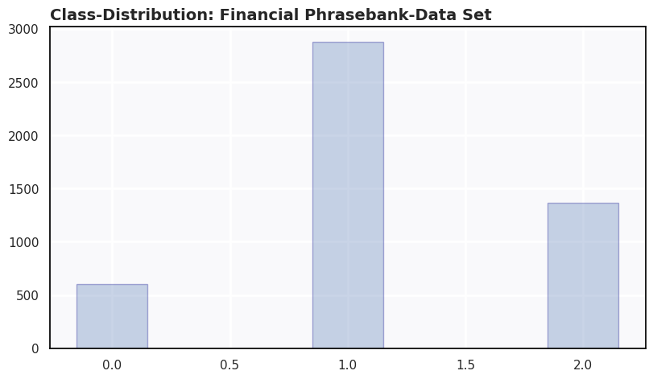

```python
fig, ax = plt.subplots(figsize = (8, 4.6), constrained_layout = True)

df_counts = df_finPB.groupby(['label']).size().reset_index(name='counts')
ax.bar(df_counts['label'], df_counts['counts'], fill = 'grey', edgecolor = 'darkblue', alpha = 0.3, width = 0.3)
ax.set_title('Class-Distribution: Financial Phrasebank-Data Set', weight ='bold', size = 14, loc = 'left');
```

According to the [HuggingFace](https://huggingface.co/datasets/financial_phrasebank) website the lables have the following meaning:

```
lables = {
  '0': 'Negative',
  '1': 'Neutral',
  '2': 'Positive'
}
```

We will save the finPB data-set to our disk and partion it into a train, test and validation split. In order to allow for reproducitility we will set a random seed based on my birthday: 11/23/1992. We transform it to a time stemp and use the first 3 numbers of the string as the random-seed.

```python
random_seed = int(str(datetime(1992, 11, 23).timestamp())[:3])
# save the dataset to disk
file_name = 'Models_Ch1_finPB.csv'
#df_finPB.to_csv(tables_dir + file_name, index = False)
# load the dataset gain
df_finPB = pd.read_csv(tables_dir + file_name)
```

```python
# we now split the data
X = df_finPB[['sentence', 'cleaned_text']]
y = df_finPB['label']
X_train, X_test, y_train, y_test = train_test_split(X, y, stratify=y, random_state=random_seed, test_size = 0.2)
```

# 2. Training and Testing Models for Sentiment Analysis

## 2.1. Loughran and McDonald (LM)—Dictionary

As stated in Ch. 1 there is no need to create a train-test-split for the dictionary case, as there is no model to be trained. In order to ensure consistency across models, we will apply the dictionary only to the test-data.

```python
# get the raw sentences
X_LM = pd.DataFrame(X_test['sentence'].copy(deep = True))
# instanciate the dictionary
LM = pysentiment2.LM()
# use the default tokenizer to process the phrases
X_LM['tokens'] = X_LM['sentence'].apply(lambda x: LM.tokenize(x))
y_LM = X_LM['tokens'].apply(lambda x: LM.get_score(x))
```

```
{'Positive': 0, 'Negative': 0, 'Polarity': 0.0, 'Subjectivity': 0.0}
```

Hence, we need now a scheme to classify the phrases. One way of doing this is by net-counting the words. We could either rely on polarity and assign values, e.g. between -0.5 and 0.5 to the neutral-class, values above 0.5 to the positive and below -0.5 to the negative or we could rely on the net-count of positive and negative words, labeling positive sentences as 1 and negative as -1 and summing up. So if the count is positive, we assign the phrase to the positive class and if it is negative, we assign to the negative class, otherwise it is neutral.

Due to the very nature of the polarity score, we know whether the net count is positive or negative by the score sign. Polarity is computed as:

\begin{align} polarity = \frac{N_{positive} - N_{negative}}{N} \end{align}

If polarity is greater (lower) than zero, then the number of positive (negative) words is greater than the number of negative (positive).

We will create a function with a lower and upper bound that allows us to predict the sentiment according to the intervals.

```python
def assign_classLM(x, lb, ub):
  """
  Function takes a pandas dataframe containing a dictionary (as string) as input, transform it to literal and
  return whether the prediction is negative (0), neutral (1), or positive (2)
  Values above the upper bound are assigned to the class positive, values below are negative and values in-between are neutral.
  """
  eval_dict = ast.literal_eval(str(x))
  polarity = eval_dict['Polarity']

  if polarity < lb:
    return 0 # negative
  elif polarity > ub:
    return 2 # positive
  else:
    return 1 # neutral

# Method 1: simple net count (lb = up = 0)
y_pred_LM_v1 = y_LM.apply(assign_classLM, lb = 0, ub = 0).copy(deep = True)

# Method 2: negative if polarity < -0.5, positive if polarity > 0.5 and neutral otherwise
y_pred_LM_v2 = y_LM.apply(assign_classLM, lb = -0.5, ub = 0.5)
```

Now that we have predictions, we can use the `scikit-learn` module to compute metrics such as precision, recall and F1-score.

LM-Dictionary Model Performance: Class Assignment Based on Net-Count of Words

Tab. 2.1.: *Table shows performance metrics based on the usage of LM-Dictionary to predict sentiment class at a phrase level. The assignment is made based on the net-count of words. If more positive (negative) than negative (positive) words are counted, the phrase is assigned to the positive (negative) class. If the net count is zero, the neutral class is assigned to the phrase.*

|  | Negative | Neutral | Positive | accuracy | macro avg | weighted avg |
| --- | --- | --- | --- | --- | --- | --- |
| precision | 0.298611 | 0.670365 | 0.466667 | 0.574227 | 0.478547 | 0.566662 |
| recall | 0.355372 | 0.734375 | 0.333333 | 0.574227 | 0.474360 | 0.574227 |
| f1-score | 0.324528 | 0.700911 | 0.388889 | 0.574227 | 0.471443 | 0.566144 |
| support | 121.000000 | 576.000000 | 273.000000 | 0.574227 | 970.000000 | 970.000000 |

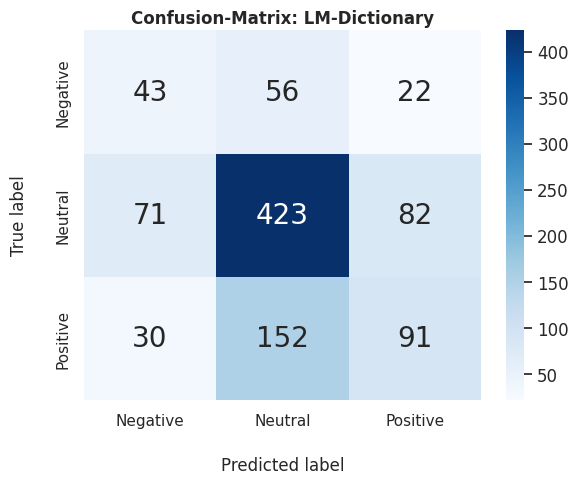

```python
LM_report_v1 = metrics.classification_report(y_test, y_pred_LM_v1, output_dict = True)
tab = creator.tabDesc(
    title = 'LM-Dictionary Model Performance: Class Assignment Based on Net-Count of Words',
    caption = "Table shows performance metrics based on the usage of LM-Dictionary to predict sentiment class at a phrase level. The assignment is made based on the net-count"\
              + " of words. If more positive (negative) than negative (positive) words are counted, the phrase is assigned to the positive (negative) class. If the net count is zero, the neutral class is assigned to the phrase.",
    type = 'Tab.',
    type_num = '2.1.',
    cap_style = 'font-size:13px; text-align:justify;',
    disp = True
)


rep_table = creator.create_report_table(LM_report_v1)
fig, ax = plot_cm(y_test, y_pred_LM_v1, labels = {'0': 'Negative', '1': 'Neutral', '2': 'Positive'}, ann_size = 20)

# Lets save this picture
ax.set_title('Confusion-Matrix: LM-Dictionary', pad = 5, weight = 'bold')
file_name = 'Models_Ch2_LM_CM.png'
#fig.savefig(driver_path + file_name, bbox_inches = 'tight')
```

As seen in the output above, accuracy is very low, only 57.42% of the phrases are correctly predicted by this method.

Recall and precision and F1-score are also not much better. An easy definition of the formulas is provided by the [website](https://iamirmasoud.com/2022/06/19/understanding-micro-macro-and-weighted-averages-for-scikit-learn-metrics-in-multi-class-classification-with-example/).

- Precision:

\begin{align}  
 \text{Precision}=\frac{TP}{TP+FP}  
 \end{align}

- Recall

\begin{align}  
 \text{Recall}=\frac{TP}{TP+FN}  
 \end{align}

- F1-Score

\begin{align}  
 \text{F1}_{\mathcal{S}}=2\frac{\text{Precision}\times\text{Recall}}{\text{Precision}+\text{Recall}}  
 \end{align}

F1-score is a better measure of model performance, because it accounts for both, false positives and false negatives, which are missing in the recall and precision formulas respectively. Hence, we will be using the macro F1-score to compare the models and choose the model with the highest score.

We choose macro-average because of the inbalance of the dataset. Another alternative would be to use the weighted average, but this would put more emphasis on the neutral class, as the class is over represented; for our case all classes are equally important.

We will calculate the model performance for the classification scheme based on intervals:

\begin{align} class_{i}=\begin{cases} \text{negative}\left(0\right) & \text{if polarity}<-0.5\\ \text{neutral }\left(1\right) & \text{if}-0.5\leq\text{polarity}\leq0.5\\ \text{positive}\left(2\right) & \text{otherwise} \end{cases} \end{align}

where $i$ relates to a phrase in the dataset.

LM-Dictionary Model Performance: Class Assignment Based on Polarity Interval

Tab. 2.2.: *Table shows performance metrics based on the usage of LM-Dictionary to predict sentiment class at a phrase level. The assignment is made based on the interval the polarity score falls in.If polarity is below -0.5, the phrase is assigned to the negative class, if polarity is greater than 0.5, it is a positive phrase, otherwise the phrase is considered to be neutral.*

|  | Negative | Neutral | Positive | accuracy | macro avg | weighted avg |
| --- | --- | --- | --- | --- | --- | --- |
| precision | 0.285714 | 0.664577 | 0.463542 | 0.570103 | 0.471278 | 0.560737 |
| recall | 0.330579 | 0.736111 | 0.326007 | 0.570103 | 0.464232 | 0.570103 |
| f1-score | 0.306513 | 0.698517 | 0.382796 | 0.570103 | 0.462609 | 0.560760 |
| support | 121.000000 | 576.000000 | 273.000000 | 0.570103 | 970.000000 | 970.000000 |

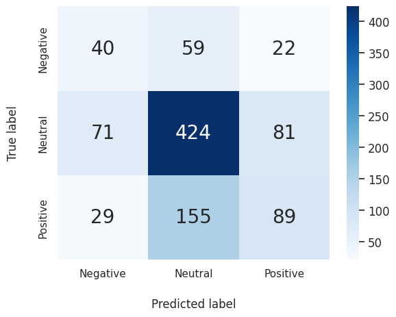

```python
LM_report_v2 = metrics.classification_report(y_test, y_pred_LM_v2, output_dict = True)
tab = creator.tabDesc(
    title = 'LM-Dictionary Model Performance: Class Assignment Based on Polarity Interval',
    caption = "Table shows performance metrics based on the usage of LM-Dictionary to predict sentiment class at a phrase level. The assignment is made based on the interval the polarity score falls in."\
              + "If polarity is below -0.5, the phrase is assigned to the negative class, if polarity is greater than 0.5, it is a positive phrase, otherwise the phrase is considered to be neutral.",
    type = 'Tab.',
    type_num = '2.2.',
    cap_style = 'font-size:13px; text-align:justify;',
    disp = True
)


rep_table = creator.create_report_table(LM_report_v2)
fig, ax = plot_cm(y_test, y_pred_LM_v2, labels = {'0': 'Negative', '1': 'Neutral', '2': 'Positive'}, ann_size = 20)
```

## 2.2. Machine Learning Approach

### 2.2.1 Model Training

#### 2.2.1.1. XGBoost

The first model that we will train and compute performance is XGBoost. XGBoost is a so-called "ensamble model". It uses sevearal "weak learnings" to build a powerful predictive model, in our case, decision trees. It starts with an intial prediction (usually the average) and build sucessively trees that aim to minimize the errors of past predictions. Further, the model allows for regularization parameters to encourage prouning of the trees and allows for specification of the max-depth of each tree.

A more detailed explaination of the model is provided by the official [paper](https://arxiv.org/pdf/1603.02754.pdf).

#### XGBoost: Model Training I (Using Raw-Data)

Just as we did with the dictionary case, we will split the data into test and train and apply 5-fold cross validation in the train set to find the best parameters and vectorization method.

We will first apply the model to the raw phrases, meaning that we will only tokenize the data.

In a second try we will use the cleaned phrases as done in Section 1 (introduction) and check whether we can achieve higher performance.

We start now by vectorizing our data using `TF-IDF` built-in method from `scikit-learn.`

We will use scikit-learn `Pipeline` to parallelize our code. I make reference to the following discussion about using Pipeline with XGboost: [Pipeline and XGBoost](https://openscoring.io/blog/2021/02/27/sklearn_tf_tfidf_xgboost_pipeline/)

In order for XGBoost to understand the data correctly (and not as missing values because of the sparse representation), we need to convert the sparse matrices from `TifidfTransformer` to its dense representation, otherwise the model will understand the "missing-values" (that are actually not missing) as NA instead of 0.

#### XGBoost: GridSearchCV for Hyperparameter tuning

#### 1. Set of Parameters (Raw Text)

Our objective function here will be to maximize the (macro)f1-score

```python
f1_scorer = make_scorer(f1_score, average = 'macro')
# get features
X = df_finPB['sentence']
y = df_finPB['label']

random_seed = int(str(datetime(1992, 11, 23).timestamp())[:3]) # I will get the first three values which are (722)
X_train, X_test, y_train, y_test = train_test_split(X, y, stratify=y, random_state=random_seed, test_size = 0.2)
```

We create our pipeline:

```python
from sklearn.utils import class_weight
classes_weights = class_weight.compute_sample_weight(
    class_weight = 'balanced',
    y = y_train
)


clf_xgb = xgb.XGBClassifier(objective='multi:softmax', num_class=3, missing=-10*30, seed=random_seed, device='cuda', booster = 'gbtree')

text_clf = Pipeline(
    steps = [
        ('vect', CountVectorizer()),
        ('tfidf', TfidfTransformer()),
        ('dense', DenseTransformer()),
        ('clf_xgb', clf_xgb)
    ]
)

parameters = {
    'vect__ngram_range': [(1, 1), (1, 2)],
    'tfidf__use_idf': [(True), (False)],
    'clf_xgb__max_depth': [3, 4, 5],
    'clf_xgb__learning_rate': [0.1, 0.05, 0.01],
    'clf_xgb__gamma': [0, 0.25, 1],
    'clf_xgb__reg_lambda': [0, 1, 5]
}
```

```python
%%time
# notice that I deleted the cell-output in order to be able to export the notebook as html
# the ipynb version does still have the output
gs_clf = GridSearchCV(text_clf, parameters, cv = 5, scoring = f1_scorer, verbose = 2)
gs_clf = gs_clf.fit(X_train, y_train, clf_xgb__sample_weight=classes_weights)
```

```python
print("Best parameters: %s", gs_clf.best_params_)
print("Best CV F1-score: %.2f", gs_clf.best_score_)
```

```
Best parameters: %s {'clf_xgb__gamma': 1, 'clf_xgb__learning_rate': 0.1, 'clf_xgb__max_depth': 5, 'clf_xgb__reg_lambda': 0, 'tfidf__use_idf': True, 'vect__ngram_range': (1, 1)}
Best CV F1-score: %.2f 0.7009978219076947
```

```python
# save the model
import pickle
#with open(driver_path + 'Models_Ch3_XGB_Raw_ParameterSet1.pkl', 'wb') as file:
    #pickle.dump(gs_clf, file)
```

```python
# load the model again
import pickle
with open(models_dir + 'Models_Ch2_XGB_Raw_ParameterSet1.pkl', 'rb') as file:
  model = pickle.load(file)
```

```python
model.best_params_
```

```
{'clf_xgb__gamma': 1,
 'clf_xgb__learning_rate': 0.1,
 'clf_xgb__max_depth': 5,
 'clf_xgb__reg_lambda': 0,
 'tfidf__use_idf': True,
 'vect__ngram_range': (1, 1)}
```

Our best model was the one with the following parameters:

```
{'clf_xgb__gamma': 1,
'clf_xgb__learning_rate': 0.1,
'clf_xgb__max_depth': 5,
'clf_xgb__reg_lambda': 0,
'tfidf__use_idf': True,
'vect__ngram_range': (1, 1)}
```

with a F1-score of 0.7009. The max-depth of the trees, the learning rate and the gamma were all corner solutions in our search. From now on we will keep `ngram_range: (1, 1)`, `tfidf(use_idf = True)` as they are. But we will do a new grid-search where we change the learning rate (trying learning rates that are higher than 0.1), trying regularization lambda that are between 0 and 1, and trying the max_depth paramater that goes above 5.

#### 2. Set of Parameters (GridSearchCV) - Using Raw Text

```python
%%time
# notice that I deleted the cell-output in order to be able to export the notebook as html
# the ipynb version does still have the output

# create a new set of parameters

xgb_newparameters = {
    'vect__ngram_range': [(1, 1)],
    'tfidf__use_idf': [(True)],
    'clf_xgb__gamma': [1, 1.25, 1.5],
    'clf_xgb__learning_rate': [0.1, 0.25, 0.5],
    'clf_xgb__max_depth': [5, 6, 8],
    'clf_xgb__reg_lambda': [0, 0.5, 0.7],
    'clf_xgb__n_estimators': [100, 200, 300]
}


gs_clf = GridSearchCV(text_clf, xgb_newparameters, cv = 5, scoring = f1_scorer, verbose = 2)
gs_clf = gs_clf.fit(X_train, y_train, clf_xgb__sample_weight=classes_weights)
```

```python
print('Best Params:\n{}\n\nBest score: {}'.format(gs_clf.best_params_, gs_clf.best_score_))
```

```
Best Params:
{'clf_xgb__gamma': 1.5, 'clf_xgb__learning_rate': 0.1, 'clf_xgb__max_depth': 6, 'clf_xgb__n_estimators': 200, 'clf_xgb__reg_lambda': 0, 'tfidf__use_idf': True, 'vect__ngram_range': (1, 1)}

Best score: 0.7110110742621767
```

There was a small improvement to the model performance from a macro averaged F1-score of 0.7009 to 0.7110. We will use this set of parameters to evaluate the model in our final test set. But before we will apply train the same model in cleaned data.

```
parameters = {
  'gamma': 1.5,
  'learning_rate': 0.1,
  'max_depth': 6,
  'n_estimators': 200,
  'reg_lambda': 0,
  'use_idf': True,
  'ngram_range': (1, 1)
}
```

```python
# Save the model
import pickle
model_name = 'Models_Ch2_XGB_Raw_ParameterSet2.pkl'

#with open(driver_path + model_name, 'wb') as file:
    #pickle.dump(gs_clf, file)

# load the model again
with open(models_dir + model_name, 'rb') as file:
  xgb_clf = pickle.load(file)
```

#### XGBoost: Model Training II (Cleaned Text)

In this section we will repeat exact the same process as in the section above, but with the difference that, instead of using tokenized raw-data, we will use the data that was first lemmatized, special characters and punctuations removed as well as the text lowered

```python
f1_scorer = make_scorer(f1_score, average = 'macro')
# get features
X = df_finPB['cleaned_text']
y = df_finPB['label']

random_seed = int(str(datetime(1992, 11, 23).timestamp())[:3]) # I will get the first three values which are (722)
X_train, X_test, y_train, y_test = train_test_split(X, y, stratify=y, random_state=random_seed, test_size = 0.2)
```

#### XGBoost: 1. Set of Parameters (Cleaned Text)

Notice that we only changed the data. We do not use the Raw-text anymore, but the cleaned one. The goals is to check whether performance can be improved.

```python
from sklearn.utils import class_weight
classes_weights = class_weight.compute_sample_weight(
    class_weight = 'balanced',
    y = y_train
)


clf_xgb = xgb.XGBClassifier(objective='multi:softmax', num_class=3, missing=-10*30, seed=random_seed, device='cuda', booster = 'gbtree')

text_clf = Pipeline(
    steps = [
        ('vect', CountVectorizer()),
        ('tfidf', TfidfTransformer()),
        ('dense', DenseTransformer()),
        ('clf_xgb', clf_xgb)
    ]
)

parameters = {
    'vect__ngram_range': [(1, 1), (1, 2)],
    'tfidf__use_idf': [(True), (False)],
    'clf_xgb__max_depth': [3, 4, 5],
    'clf_xgb__learning_rate': [0.1, 0.05, 0.01],
    'clf_xgb__gamma': [0, 0.25, 1],
    'clf_xgb__reg_lambda': [0, 1, 5]
}
```

```python
# notice that I deleted the cell-output in order to be able to export the notebook as html (check ipynb version for output)
# the ipynb version does still have the output
%%time

gs_clf = GridSearchCV(text_clf, parameters, cv = 5, scoring = f1_scorer, verbose = 2)
gs_clf = gs_clf.fit(X_train, y_train, clf_xgb__sample_weight=classes_weights)
```

We next check the best parameters found by the model and save it.

```python
print("Best parameters: %s", gs_clf.best_params_)
print("Best CV F1-score: %.2f", gs_clf.best_score_)
```

```
Best parameters: %s {'clf_xgb__gamma': 0.25, 'clf_xgb__learning_rate': 0.1, 'clf_xgb__max_depth': 5, 'clf_xgb__reg_lambda': 0, 'tfidf__use_idf': False, 'vect__ngram_range': (1, 1)}
Best CV F1-score: %.2f 0.6938801502658178
```

```python
# save the model
import pickle
#with open(driver_path + 'Models_Ch2_XGB_Cleaned_ParameterSet1.pkl', 'wb') as file:
    #pickle.dump(gs_clf, file)

with open(models_dir + 'Models_Ch2_XGB_Cleaned_ParameterSet1.pkl', 'rb') as file:
  model = pickle.load(file)

model.best_params_
```

```
{'clf_xgb__gamma': 0.25,
 'clf_xgb__learning_rate': 0.1,
 'clf_xgb__max_depth': 5,
 'clf_xgb__reg_lambda': 0,
 'tfidf__use_idf': False,
 'vect__ngram_range': (1, 1)}
```

the best set of parameters of the model computed using the raw text for the first run was:

```
{'clf_xgb__gamma': 1,
 'clf_xgb__learning_rate': 0.1,
 'clf_xgb__max_depth': 5,
 'clf_xgb__reg_lambda': 0,
 'tfidf__use_idf': True,
 'vect__ngram_range': (1, 1)}
```

The new set of best parameters based on the cleaned data is

```
{'clf_xgb__gamma': 0.25,
'clf_xgb__learning_rate': 0.1,
'clf_xgb__max_depth': 5,
'clf_xgb__reg_lambda': 0,
'tfidf__use_idf': False,
'vect__ngram_range': (1, 1)}
```

surprisingly the macro-averaged F1-score for the model based on the cleaned-data is worse than the model computed using the raw-data.

We will again try a new set of parameters

#### XGboost: 2. Set of Parameters (Cleaned Text)

```python
%%time

# notice that I deleted the cell-output in order to be able to export the notebook as html  (check ipynb version for output)
# create a new set of parameters

xgb_newparameters = {
    'vect__ngram_range': [(1, 1)],
    'tfidf__use_idf': [(False)],
    'clf_xgb__gamma': [0.1, 0.25, 0.5],
    'clf_xgb__learning_rate': [0.1, 0.05, 0.02],
    'clf_xgb__max_depth': [5, 6, 8],
    'clf_xgb__reg_lambda': [0, 0.2, 0.5],
    'clf_xgb__n_estimators': [100, 200, 300]
}


gs_clf = GridSearchCV(text_clf, xgb_newparameters, cv = 5, scoring = f1_scorer, verbose = 2)
gs_clf = gs_clf.fit(X_train, y_train, clf_xgb__sample_weight=classes_weights)
```

We print the best set of parameters and save the model

```python
print("Best parameters: %s", gs_clf.best_params_)
print("Best CV F1-score: %.2f", gs_clf.best_score_)
```

```
Best parameters: %s {'clf_xgb__gamma': 0.25, 'clf_xgb__learning_rate': 0.05, 'clf_xgb__max_depth': 5, 'clf_xgb__n_estimators': 300, 'clf_xgb__reg_lambda': 0, 'tfidf__use_idf': False, 'vect__ngram_range': (1, 1)}
Best CV F1-score: %.2f 0.698967044709785
```

```python
# save the model
import pickle
#with open(driver_path + 'Models_Ch2_XGB_Cleaned_ParameterSet2.pkl', 'wb') as file:
    #pickle.dump(gs_clf, file)
with open(models_dir + 'Models_Ch2_XGB_Cleaned_ParameterSet2.pkl', 'rb') as file:
  model = pickle.load(file)
```

#### 2.2.1.2. Support Vector Machine Classifier (Multiclass)

In this section we will repeat the process as we did with XGBoost. We will split the data into train and test. Use the train data to find the best hyperparameters for the support-vector machine classifier.

In the first run, we will train the model on the raw-data and in a second step, we train the model using the cleaned data (lemmatized, no special character and punctuation, no stop-words).

#### SVM: Model Training I (Raw Data)

```python
# get features
X = df_finPB['sentence']
y = df_finPB['label']

random_seed = int(str(datetime(1992, 11, 23).timestamp())[:3]) # I will get the first three values which are (722)
X_train, X_test, y_train, y_test = train_test_split(X, y, stratify=y, random_state=random_seed, test_size = 0.2)
```

We will implement the SVC as explained by [scikit-learn](https://scikit-learn.org/stable/modules/svm.html#svm) implementation. We do gridsearchCV to text different Kernels and different values of regularization for $C$ and $\gamma$.

#### SVM: GridSearchCV for Hyperparameter tuning

#### SVM: 1. Set of Parameters (Raw Data)

We now again use GridSearchCV to serch for the best combination of parameters. As in the XGBoost case, we use the default vectorization function of scikit-learn to create first a vector based on the count of words (bag of words), it is then transformed to a term matrix, whether this term matrix is then transformed using inverse-document frequency is one of the parameters to be tested.

We fit the SVM with linear, poly, rbf and sigmoid kernels, and try different values for the regularization parameters $\gamma$ and $C$.

```python
from sklearn.svm import SVC
from sklearn.utils import class_weight
from sklearn.model_selection import GridSearchCV

# create F1-Scorer
f1_scorer = make_scorer(f1_score, average = 'macro')
clf_svm = SVC()
# create a pipeline
text_clf_svm = Pipeline(
    steps = [
        ('vect', CountVectorizer()),
        ('tfidf', TfidfTransformer()),
        #('dense', DenseTransformer()), Notice that we do not need to transform the matrix to its dense form as both models come from scikit-learn
        # and scikit-learn handles it automatically.
        ('clf_svm', clf_svm)
    ]
)

parameters_1st_svm = {
    'vect__ngram_range': [(1, 1), (1, 2)],
    'tfidf__use_idf': [(True), (False)],
    'clf_svm__kernel': ['linear', 'poly', 'rbf', 'sigmoid'],
    'clf_svm__gamma': [10e-1, 10e-2, 10e-3],
    'clf_svm__C': [0.1, 0.25, 0.5, 1]

}
```

```python
%%time
# notice that I deleted the cell-output in order to be able to export the notebook as html  (check ipynb version for output)
gs_clf_svm = GridSearchCV(text_clf_svm, parameters_1st_svm, scoring = f1_scorer, cv = 5, verbose = 2)
gs_clf_svm = gs_clf_svm.fit(X_train, y_train)
```

We will now save this model

```python
import pickle
model_name = 'Models_Ch2_SVM_Raw_ParameterSet1.pkl'

# save the model
#with open(driver_path + model_name, 'wb') as file:
    #pickle.dump(gs_clf_svm, file)

# load the model again
with open(models_dir + model_name, 'rb') as file:
  svm_clf = pickle.load(file)
```

```python
print('Best-Set of parameters SVM: \n{}'.format(svm_clf.best_params_))
print('Macro-Averaged F1-score: {}'.format(svm_clf.best_score_))
```

```
Best-Set of parameters SVM:
{'clf_svm__C': 1, 'clf_svm__gamma': 1.0, 'clf_svm__kernel': 'linear', 'tfidf__use_idf': True, 'vect__ngram_range': (1, 2)}
Macro-Averaged F1-score: 0.6984971908240413
```

```python
svm_clf.best_params_
```

```
{'clf_svm__C': 1,
 'clf_svm__gamma': 1.0,
 'clf_svm__kernel': 'linear',
 'tfidf__use_idf': True,
 'vect__ngram_range': (1, 2)}
```

Recall that the first set of parameters that we tried was

```
parameters_1st_svm = {
    'vect__ngram_range': [(1, 1), (1, 2)],
    'tfidf__use_idf': [(True), (False)],
    'clf_svm__kernel': ['linear', 'poly', 'rbf', 'sigmoid'],
    'clf_svm__gamma': [10e-1, 10e-2, 10e-3],
    'clf_svm__C': [0.1, 0.25, 0.5, 1]

}
```

The optimal parameters (the one that maximized the macro-averaged F1-scored) were

```
optimal_params = {'clf_svm__C': 1,
 'clf_svm__gamma': 1.0,
 'clf_svm__kernel': 'linear',
 'tfidf__use_idf': True,
 'vect__ngram_range': (1, 2)}
```

We will next try another set of parameters, but will keep the use of TF-IDF, n-gram (1, 2). And try other values for gamma and C along with different kernels.

#### SVM: 2. Set of Parameters (Raw Data)

```python
from sklearn.svm import SVC
from sklearn.utils import class_weight
from sklearn.model_selection import GridSearchCV

# create F1-Scorer
f1_scorer = make_scorer(f1_score, average = 'macro')
clf_svm = SVC()
# create a pipeline
text_clf_svm = Pipeline(
    steps = [
        ('vect', CountVectorizer()),
        ('tfidf', TfidfTransformer()),
        #('dense', DenseTransformer()), Notice that we do not need to transform the matrix to its dense form as both models come from scikit-learn
        # and scikit-learn handles it automatically.
        ('clf_svm', clf_svm)
    ]
)

parameters_2nd_svm = {
    'vect__ngram_range': [(1, 2)],
    'tfidf__use_idf': [(True)],
    'clf_svm__kernel': ['linear', 'poly', 'rbf', 'sigmoid'],
    'clf_svm__gamma': [0.5, 1, 1.5],
    'clf_svm__C': [1, 1.5, 2, 2.5]

}
```

```python
%%time
# notice that I deleted the cell-output in order to be able to export the notebook as html  (check ipynb version for output)
gs_clf_svm = GridSearchCV(text_clf_svm, parameters_2nd_svm, scoring = f1_scorer, cv = 5, verbose = 2)
gs_clf_svm = gs_clf_svm.fit(X_train, y_train)
```

We now save the model and load it in again:

```python
import pickle
model_name = 'Models_Ch2_SVM_Raw_ParameterSet2.pkl'

# save the model
#with open(driver_path + model_name, 'wb') as file:
    #pickle.dump(gs_clf_svm, file)

# load the model again
with open(models_dir + model_name, 'rb') as file:
  svm_clf = pickle.load(file)
```

```python
print('Best-Set of parameters SVM: \n{}'.format(svm_clf.best_params_))
print('Macro-Averaged F1-score: {}'.format(svm_clf.best_score_))
```

```
Best-Set of parameters SVM:
{'clf_svm__C': 2, 'clf_svm__gamma': 0.5, 'clf_svm__kernel': 'linear', 'tfidf__use_idf': True, 'vect__ngram_range': (1, 2)}
Macro-Averaged F1-score: 0.7215197793072555
```

#### SVM Model Training II (Cleaned data)

In this section, we will train the model again, but using the cleaned data (see Section 1 - Introduction for further details on the cleaning) to check whether we can achieve higher performance. We start by doing train-test split. Again we use the random-seed common to all other models.

```python
# get features
X = df_finPB['cleaned_text']
y = df_finPB['label']

random_seed = int(str(datetime(1992, 11, 23).timestamp())[:3]) # I will get the first three values which are (722)
X_train, X_test, y_train, y_test = train_test_split(X, y, stratify=y, random_state=random_seed, test_size = 0.2)
```

#### SVM: 1. Set of Parameters (Cleaned Text)

We will start with almost the same set of parameters to be tried as we used for the raw-text. But we will also try n-grams combinations of (1, 3)

```python
from sklearn.svm import SVC
from sklearn.utils import class_weight
from sklearn.model_selection import GridSearchCV

# create F1-Scorer
f1_scorer = make_scorer(f1_score, average = 'macro')
clf_svm = SVC()
# create a pipeline
text_clf_svm = Pipeline(
    steps = [
        ('vect', CountVectorizer()),
        ('tfidf', TfidfTransformer()),
        #('dense', DenseTransformer()), Notice that we do not need to transform the matrix to its dense form as both models come from scikit-learn
        # and scikit-learn handles it automatically.
        ('clf_svm', clf_svm)
    ]
)

parameters_1st_svm = {
    'vect__ngram_range': [(1, 1), (1, 2), (1, 3)],
    'tfidf__use_idf': [(True), (False)],
    'clf_svm__kernel': ['linear', 'poly', 'rbf', 'sigmoid'],
    'clf_svm__gamma': [10e-1, 10e-2, 10e-3],
    'clf_svm__C': [0.1, 0.25, 0.5, 1]

}
```

```python
%%time
# notice that I deleted the cell-output in order to be able to export the notebook as html  (check ipynb version for output)
gs_clf_svm = GridSearchCV(text_clf_svm, parameters_1st_svm, scoring = f1_scorer, cv = 5, verbose = 2)
gs_clf_svm = gs_clf_svm.fit(X_train, y_train)
```

We save the model.

```python
import pickle
model_name = 'Models_Ch2_SVM_Cleaned_ParameterSet1.pkl'

# save the model
#with open(driver_path + model_name, 'wb') as file:
    #pickle.dump(gs_clf_svm, file)

# load the model again
with open(models_dir + model_name, 'rb') as file:
  svm_clf = pickle.load(file)
```

Next we check the performance of the model and test another set of parameters.

```python
print('Best-Set of parameters SVM: \n{}'.format(svm_clf.best_params_))
print('Macro-Averaged F1-score: {}'.format(svm_clf.best_score_))
```

```
Best-Set of parameters SVM:
{'clf_svm__C': 1, 'clf_svm__gamma': 1.0, 'clf_svm__kernel': 'linear', 'tfidf__use_idf': True, 'vect__ngram_range': (1, 2)}
Macro-Averaged F1-score: 0.6769472748462265
```

The best set of parameters is identical to the first set tried on the uncleaned-data. And, similar to XGBoost case, the f1-score is lower when we remove punctuation, special characters, stop words and lemmatize the phrase.

#### SVM: 2. Set of Parameters (Cleaned Text)

Given that the first set optimal parameters is identically to the ones of the model trained on the raw-data, we will try the exactly same second set of parameters to try to improve performance.

```python
from sklearn.svm import SVC
from sklearn.utils import class_weight
from sklearn.model_selection import GridSearchCV

# create F1-Scorer
f1_scorer = make_scorer(f1_score, average = 'macro')
clf_svm = SVC()
# create a pipeline
text_clf_svm = Pipeline(
    steps = [
        ('vect', CountVectorizer()),
        ('tfidf', TfidfTransformer()),
        #('dense', DenseTransformer()), Notice that we do not need to transform the matrix to its dense form as both models come from scikit-learn
        # and scikit-learn handles it automatically.
        ('clf_svm', clf_svm)
    ]
)

parameters_2nd_svm = {
    'vect__ngram_range': [(1, 2)],
    'tfidf__use_idf': [(True)],
    'clf_svm__kernel': ['linear', 'poly', 'rbf', 'sigmoid'],
    'clf_svm__gamma': [0.5, 1, 1.5],
    'clf_svm__C': [1, 1.5, 2, 2.5]

}
```

```python
%%time
# notice that I deleted the cell-output in order to be able to export the notebook as html  (check ipynb version for output)
gs_clf_svm = GridSearchCV(text_clf_svm, parameters_2nd_svm, scoring = f1_scorer, cv = 5, verbose = 2)
gs_clf_svm = gs_clf_svm.fit(X_train, y_train)
```

we now save the model

```python
import pickle
model_name = 'Models_Ch2_SVM_Cleaned_ParameterSet2.pkl'

# save the model
#with open(driver_path + model_name, 'wb') as file:
    #pickle.dump(gs_clf_svm, file)

# load the model again
with open(models_dir + model_name, 'rb') as file:
  svm_clf = pickle.load(file)
```

```python
print('Best-Set of parameters SVM: \n{}'.format(svm_clf.best_params_))
print('Macro-Averaged F1-score: {}'.format(svm_clf.best_score_))
```

```
Best-Set of parameters SVM:
{'clf_svm__C': 2.5, 'clf_svm__gamma': 0.5, 'clf_svm__kernel': 'linear', 'tfidf__use_idf': True, 'vect__ngram_range': (1, 2)}
Macro-Averaged F1-score: 0.6879661121802669
```